# Data Science and Data Analytics

## Step 3 – Identify if additional sources are needed

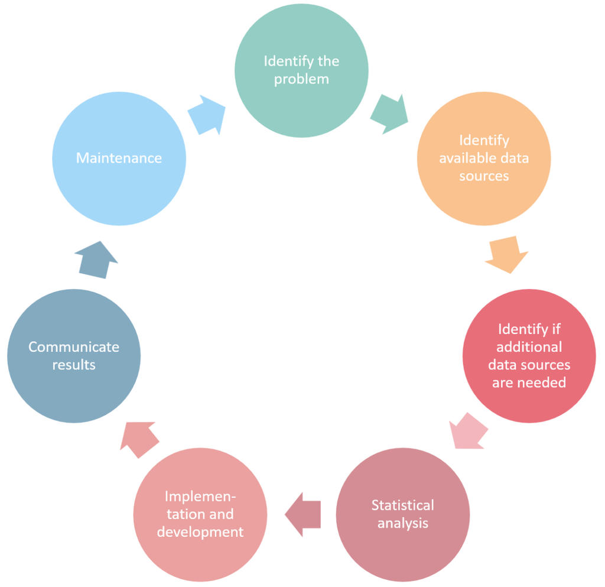

## Step 4 – Statistical analysis

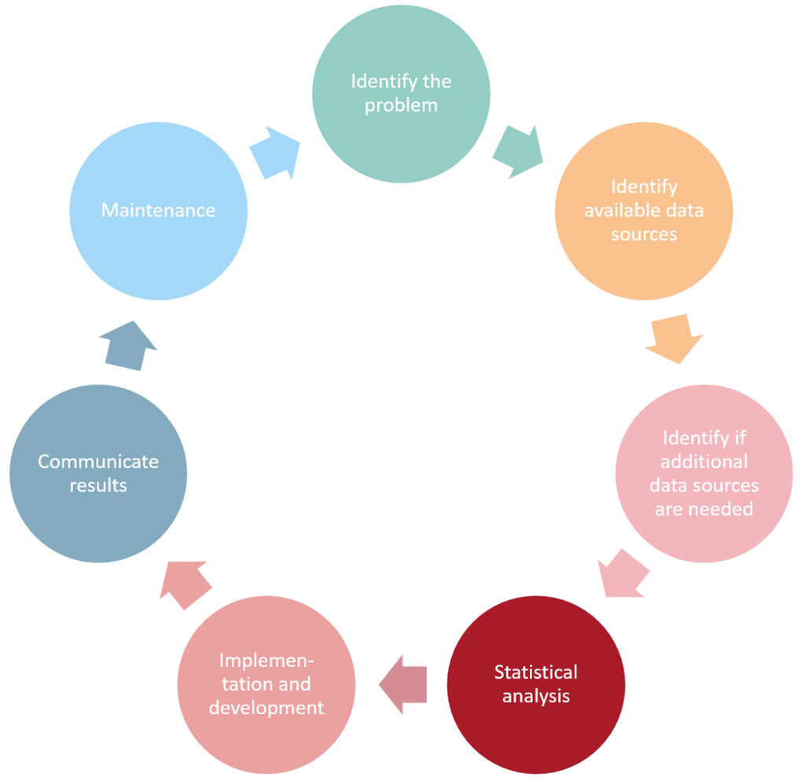

## Step 4 – Statistical analysis

- After data has been obtained, the data scientist needs to clean, process and explore it. This can involve:
  - Handling missing values, outliers, and noise.
  - **Exploratory data analysis (EDA)**: Visualizations, correlation analysis, and summary statistics.
- Based on clean data, **statistical tests** can be employed to validate existing business hypotheses. Here, all the tests you have (hopefully) learned in your statistics classes come in, e.g. T-tests, ANOVA, $\chi^2$ tests, etc.
- Through this process, the data scientist can start to develop an **understanding** of the data.

## Step 5 – Implementation and development

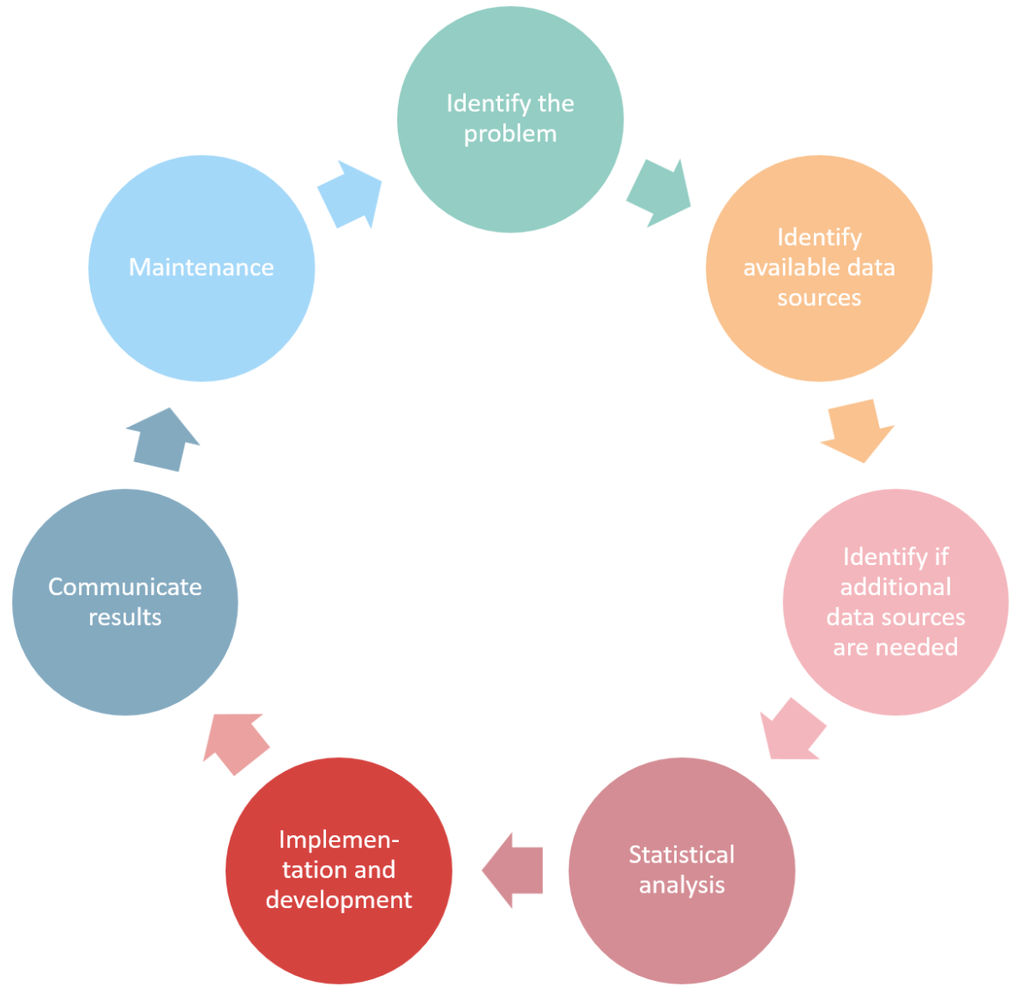

## Step 5 – Implementation and development

- After familiarizing themselves with the data, data scientists then have to **translate insights into action**. This involves offering some kind of product back to the business.
- This could take the form of:
  - Training and deploying a **machine learning model**, e.g. offering the business a model that tells them the probability that a given customer will churn.
  - Building **dashboards** to make the data-driven insights accessible to non-technical people in business.
  - Support strategic decision making by providing appropriate statistics, figures, graphs and other data.

## Step 5 – Implementation and development

[figure not shown]

## Step 6 – Communicate results

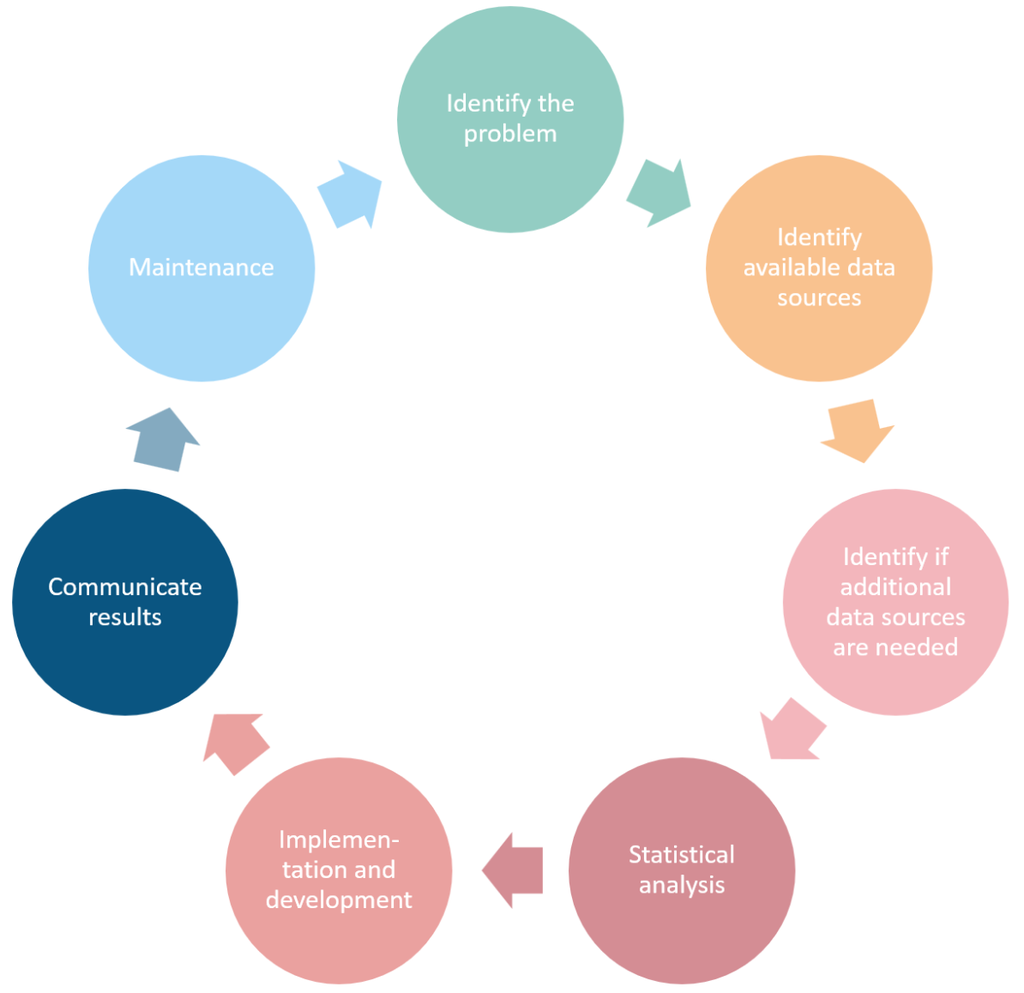

## Step 6 – Communicate results

- Communication is an often underappreciated aspect of data science in business: any data insight can only be as good as it can be made understood by the people that (should) act on it.
- Key communication goals:
  - **Simplify** complex technical details without losing accuracy.
  - **Tailor the message to your audience** (executives, technical teams, clients).
- Communication strategies:
  - **Visual storytelling**: Use charts, graphs, and dashboards to highlight trends and key metrics.
  - **Narrative & context**: Frame results within a business story: What problem was solved? How do the results impact the business?
  - **Actionable insights**: Include clear recommendations and next steps.

## Step 7 – Maintenance

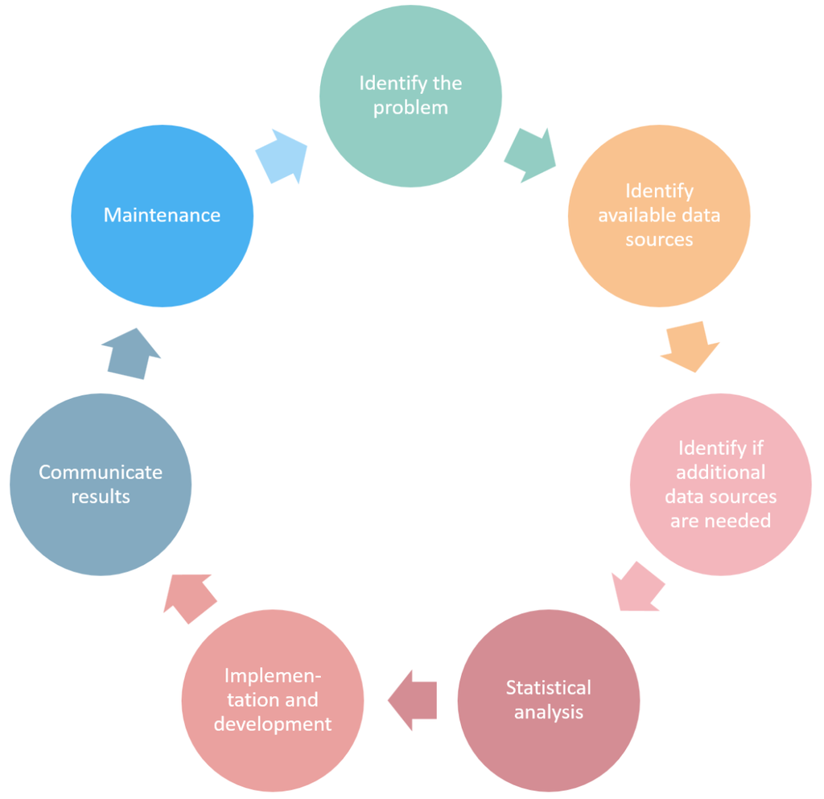

## Step 7 – Maintenance

- Once a **data science product** like a machine learning model or a dashboard is “in production”, i.e. is used by business, it will not age like fine wine…
- Instead, changes in data over time and general [software rot](https://en.wikipedia.org/wiki/Software_rot) will quickly cause the product to be useless if left unchanged.
- Hence, data scientists need to subject their products to continuous **maintenance**:
  - **Monitor performance over time**: track metrics to detect data drift or deterioration in model performance.
  - **Update models and systems**: retrain models with new data when necessary.
  - Regularly engage stakeholders for **feedback**
  - Identify new problems and areas for improvement and **restart** the cycle.

## The essence of Data Science

- Data science is a demanding field that requires skills in maths, statistics and computer science, but also high levels of **domain expertise** and **excellent communication**.
- Thus, it is impossible to cover all areas of DS in a single course…
- This course focuses on what could be called the **essence of data science**:
  - Statistical analysis
  - Implementation and development
  - Communication of results
- We will further break these steps down in the **data science workflow**.

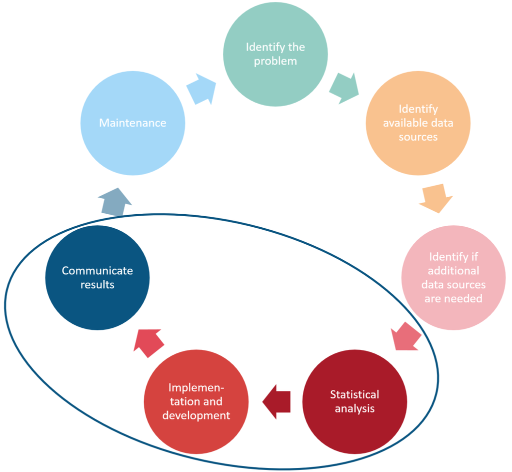

# The Data Science workflow

## The Data Science workflow

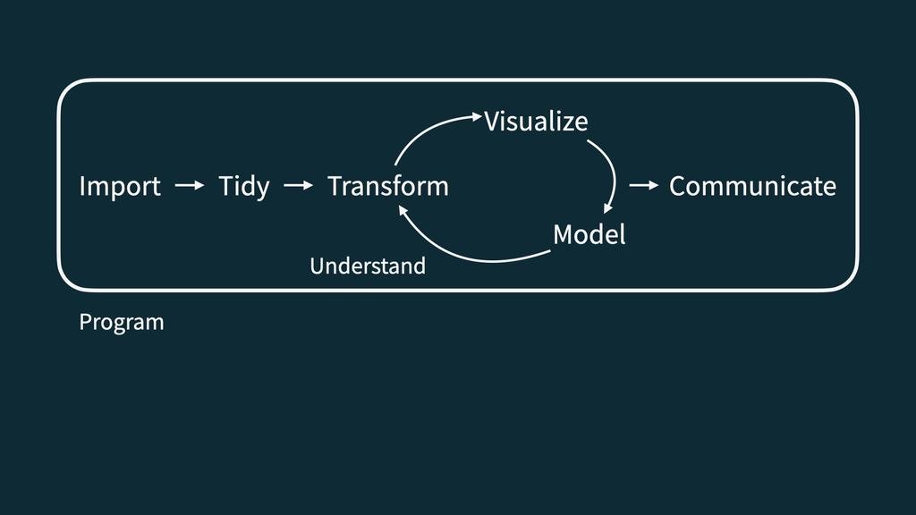

Source: [Wickham et al. (2023)](https://r4ds.hadley.nz/)

## The Data Science workflow – Part I

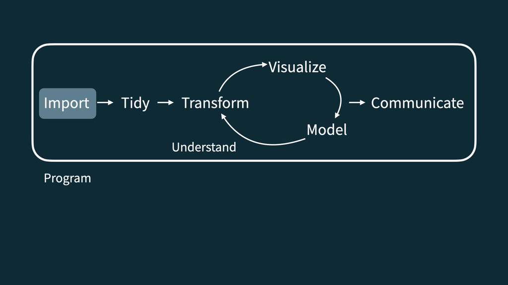

Source: [Wickham et al. (2023)](https://r4ds.hadley.nz/)

## The Data Science workflow – Part I

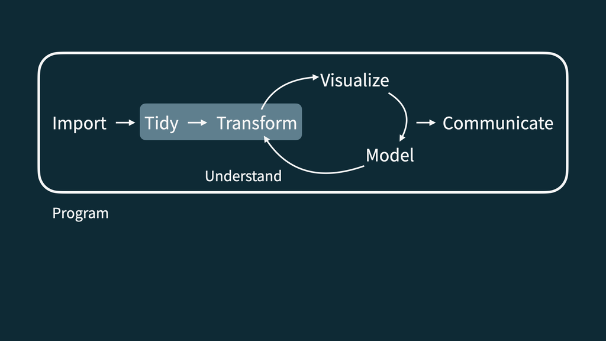

Source: [Wickham et al. (2023)](https://r4ds.hadley.nz/)

## The Data Science workflow – Part II

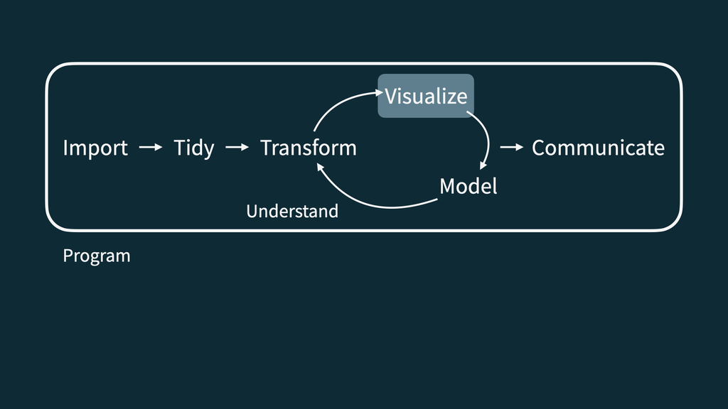

Source: [Wickham et al. (2023)](https://r4ds.hadley.nz/)

## The Data Science workflow – Part III

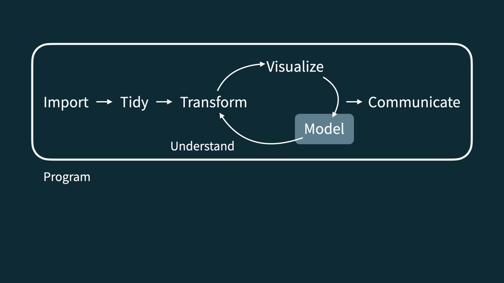

Source: [Wickham et al. (2023)](https://r4ds.hadley.nz/)

## The Data Science workflow – Understanding data

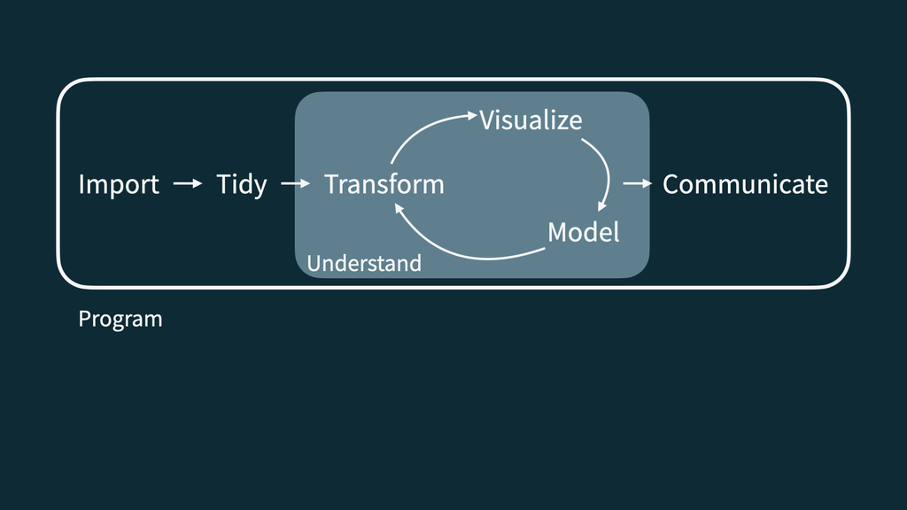

Source: [Wickham et al. (2023)](https://r4ds.hadley.nz/)

## The Data Science workflow – Part IV

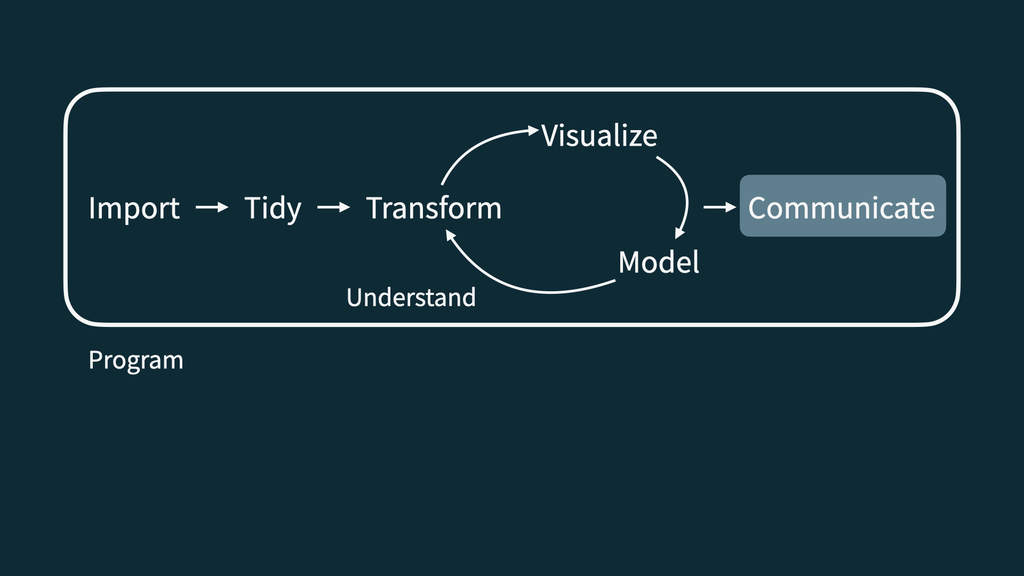

Source: [Wickham et al. (2023)](https://r4ds.hadley.nz/)

## The Data Science workflow – How? Program!

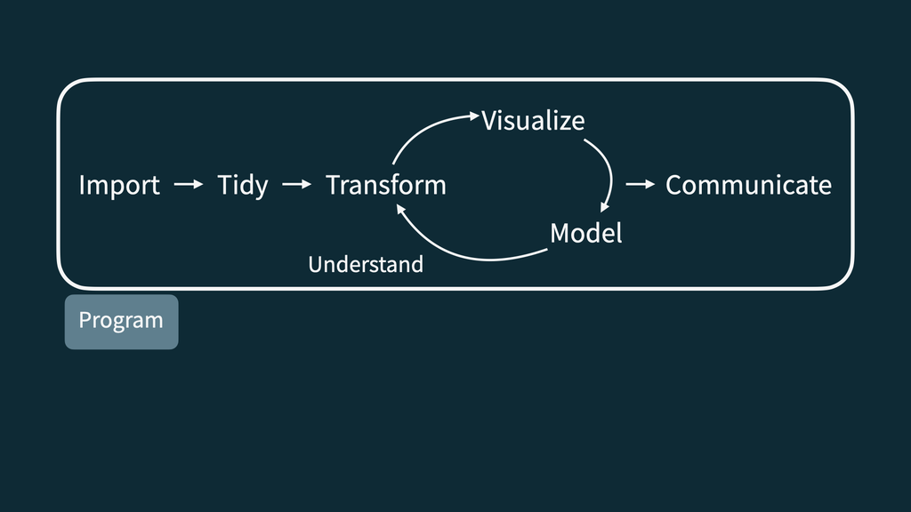

Source: [Wickham et al. (2023)](https://r4ds.hadley.nz/)

## How about Data Analytics?

- The name of the course is **Data Science and Data Analytics**, but only data science has been mentioned so far. How about data analytics?
- Essentially, **data analytics** is data science without the strong computer science and machine learning focus. Therefore, the steps involved in data analytics are typically a subset of the steps in a data science project:

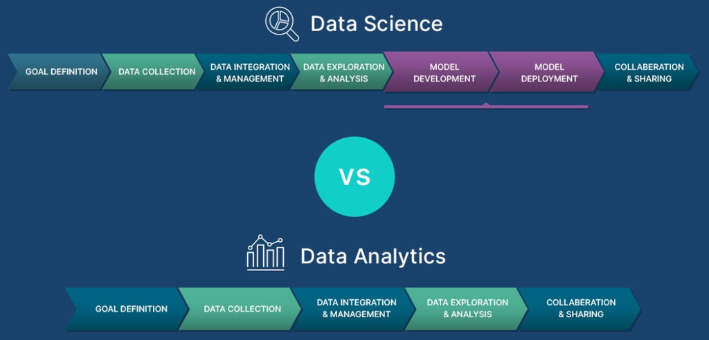

## How about Data Analytics?

The two fields thus have a **large intersection**, which is also reflected in the tasks that data scientists and data analysts share:

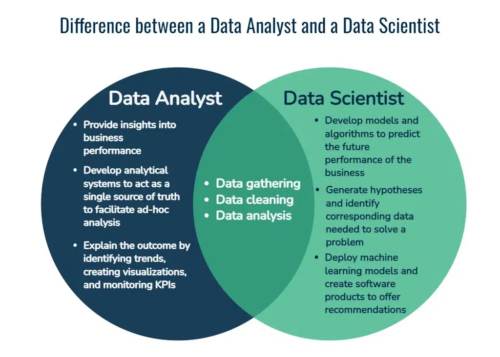

As we are focused on tasks in the intersection, we will mostly be referring to **data science** as the overarching topic in the remainder of this course.